# CRISP-DM Application and RMarkdown

Management of Reproducible ML Analysis

# Introduction

## Preliminary setup

The objective of this exercise is to produce an **analysis of the profitability of French films**.

Precisely we want to be able to predict the profitability of a French film according to its budget.

This analysis must follow the CRISP-DM model and be reproducible with R using a reproducible document such as an analysis report.

The data analytics method used here is a simple linear regression, we will learn more about this method in a later session. The focus of this application is on CRISP and RMarkdown.

First step is to setup your softwares and files

- We use R and RStudio softwares
- Once their are installed, you can open RStudio and install the following packages.  
  Installation can be done via panel `packages` and button `install` or via the console and the instruction: `install.packages("new.package.name")`: - `ggplot2`: useful for graphics - `dplyr`: useful to handle data - `knitr`: useful to display your analysis in reproducible document - `rmdformats`: useful to use html style format - `skimr`: useful to display summary statistics of data
- Next, you will organize your project, which will contain data base, R instruction files, your final document, etc.  
  On your operating system, you will create a new folder in your hard-drive (or usb key, etc). We recommend not to use windows user folders and avoid specific characters, like `é @ #` in the path and folders names.
- For this exercise, you can store all files in the same unique folder. At the end few objects will be generated. In the future, we recommend to have a “data” subfolder and for example “Fig”, “Bib”, etc to store images, bibliographic references, etc.
- Finally, you can copy the files of this exercise in the folder you have created, and open the `APPLI_CRISP_RMD_BasicDoc_SIE.Rmd` file with RStudio.  
  You can observe that it contains:
1. 15 lines of preamble, identified with `---` symbols. It define the type of document, author, date, title, etc. We will generate a webpage (html document) (using the `readthedown`format from `rmdformats` package in the “*expert*” version). You can see on **line 9** that a ‘.bib’ file is loaded. No specific path is mentioned, hence the file is supposed to be stored in the same folder as the ‘.Rmd’ file
2. 30 lines of text correspond to the text you are actually reading :-)
3. Next you find the first chunck of r instructions, identified by:

   `{r echo=FALSE}`

Several options maybe be precised in the `{}`

*Options that control what’s shown in the final document*

| Chunk option | Executes code | Shows code | Shows output text | Shows figures |
| --- | --- | --- | --- | --- |
| results=‘hide’ | X | X |  | X |
| include=FALSE | X |  |  |  |
| echo=FALSE | X |  | X | X |
| fig.show=‘hide’ | X | X | X |  |
| eval=FALSE |  | X |  |  |

4. The end of the `.Rmd` file is constituted of text and chuncks. Some chuncks will produce elements that will be displayed in the html output file (for ex: graphics, tables, etc)

You can now add your own text in the file or your own instructions in the chunck (you can add a new chunck clicking the green button: `insert a new code chunck`)

## Organisation of the report

Each part of this report makes up one of the tabs of the html document

### 1. RMarkdown preparation

**To make sure that you can work in RMarkdown: knit this Rmd document to generate the statement**

#### 1st knit of the document

You could meet several blocking points :

- Installing the packages: the 1st chunk loads the four following packages: **they must be installed on your machine** before they can be loaded

```
library(ggplot2)
library(knitr)
library(rmdformats)
library(skimr)   #  to provide summary statistics
```

```
output:
  rmdformats::readthedown
```

- You can replace it with another format from this package (for example: `rmdformats::material` or `rmdformats::html_docco`)

#### Loading the database

The data are accessible in R format :`Movie.Data.DE.RData`. This file should be placed in the same folder as the Rmd document. A simple instruction `load("Movie.Data.RData")` can be modified to specify a relative path to the position of the Rmd file : `load("../data/Movie.Data.DE.RData")`

The database [^1] describes 5,000 films according to director, producer, actors, number of admissions, audience ratings, etc.

The version proposed in this exercise is an adaptation of these data

Here we load the database

```r
load("../data/Movie.Data.DE.RData")
FrenchFilms <- Movie.Data.DE[Movie.Data.DE$country=='France',]
```

### 2. Define project and stakeholders

##### Question ————————————————————-

Given the data science project: French films profitability analysis, we want to increase the profit of French films that will be produced in the future based on the history data. So,

- (*Let start a simple role playing game*) Who is your client ?

##### Your answers (please write down your answer here)

### 3. Project workflow

Fill in the 6 phases of CRISP-DM for the French films profitability analysis project.

Just give some short answers with some logical arguments. You do not need to deep into detail here. We’ll do this at part 4 and 5.

#### *Define a goal (measurable and quantifiable)*

```
* Why do the sponsors want in the first place?
* What do they lack now, and what do they need?
* What are they doing to solve the problem now, and why isn’t that good enough?
* What resources (in terms of human and material) will we need to achieve that goal ?
* What project plan should I propose ?
```

##### Your answers (please write down your answer here)

#### *Collect and manage data*

```
* What data are currently available? Are they enough/redundant and with good/bad quality?
* What should be collected if not enough?
* What should be removed if redundant?
* What should be repaired if having bad quality?
```

##### Your answers (please write down your answer here)

#### *Build the model*. What model should I use ?

```
* Classifying: belonging to one category or another ?
* Scoring: predicting a numeric value ?
* Ranking: ordering items by preferences ?
* Clustering: grouping items into most-similar groups ?
```

##### Your answers (please write down your answer here)

#### *Evaluate & criticise model*

```
* Is it accurate enough for your needs?
* Does it generalize well?
* Does it perform better than “the obvious guess”? Better than whatever estimate you currently use?
```

*If your answer is “no” for any of these three questions, you need to go back to the modeling step or decide that the data do not support the goal you are trying to achieve. This might mean defining more-realistic goals or gathering the additional data or other resources that you need to achieve your original goals.*

##### Your answers (please write down your answer here)

#### *Present results and document models*

```
* What should I present to the sponsor and client (end user)?
* What should I present to other data scientists in my team?
* What should I present to data architect or system architect?
* What documents would be useful for using, running and maintaining the model?
```

##### Your answers (please write down your answer here)

#### *Deploy models*

```
* How could I deploy the model at a small scale?
* How to increase the deployment scale step by step?
* Client feedback and model update, how to manage these things?
```

##### Your answers (please write down your answer here)

### 4. Data manipulation

#### Explore initial data

In a first step we first check the nature of each variable (numeric, character, etc)

##### Verify data types of variables

```r
str(FrenchFilms)
```

```
## 'data.frame':    154 obs. of  6 variables:
##  $ country   : Factor w/ 66 levels "","Afghanistan",..: 21 21 21 21 21 21 21 21 21 21 ...
##  $ title_year: int  2008 2010 1997 2015 2006 2009 2015 2005 2004 1998 ...
##  $ budget    : num  7.8e+07 1.0e+08 9.3e+07 NA 8.6e+07 ...
##  $ profit    : num  NA -64975525 -29459980 NA -70868670 ...
##  $ duration  : int  116 115 126 81 94 104 108 163 109 143 ...
##  $ color     : Factor w/ 3 levels ""," Black and White",..: 3 3 3 3 3 3 3 3 3 3 ...
```

In the second step we explore the summary statistics of the data

##### Create summary statistics

```r
kable(summary(FrenchFilms))
```

|  | country | title_year | budget | profit | duration | color |
| --- | --- | --- | --- | --- | --- | --- |
|  | France :154 | Min. :1964 | Min. : 4500 | Min. :-375868702 | Min. : 52.0 | : 0 |
|  | : 0 | 1st Qu.:2002 | 1st Qu.: 9125000 | 1st Qu.: -25324770 | 1st Qu.: 94.0 | Black and White: 8 |
|  | Afghanistan: 0 | Median :2006 | Median : 19715000 | Median : -9250346 | Median :105.0 | Color :146 |
|  | Argentina : 0 | Mean :2005 | Mean : 30672035 | Mean : -15616913 | Mean :108.9 | NA |
|  | Aruba : 0 | 3rd Qu.:2011 | 3rd Qu.: 40000000 | 3rd Qu.: -465342 | 3rd Qu.:118.0 | NA |
|  | Australia : 0 | Max. :2016 | Max. :390000000 | Max. : 120000989 | Max. :334.0 | NA |
|  | (Other) : 0 | NA’s :2 | NA’s :24 | NA’s :48 | NA | NA |

The `summary()` function is a base function in R that gives an overview distinguishing categorical variable and quantitative variable.

`skim()` function gives another table of summary statistics, with complementary indicators. We apply it on the full data base instead of the French movies database.

We specify either only numeric fields or character fields.

```r
#kable(skim(Movie.Data.DE)) # another way to have a summary statistics and for all the fields
kable(skim(Movie.Data.DE[,c(-1,-6)])) # only numeric fields, exclude columns 1 & 6
```

| skim_type | skim_variable | n_missing | complete_rate | numeric.mean | numeric.sd | numeric.p0 | numeric.p25 | numeric.p50 | numeric.p75 | numeric.p100 | numeric.hist |
| --- | --- | --- | --- | --- | --- | --- | --- | --- | --- | --- | --- |
| numeric | title_year | 106 | 0.9784421 | 2002.444 | 1.245584e+01 | 1916 | 1999 | 2005 | 2011 | 2016 | ▁▁▁▂▇ |
| numeric | budget | 484 | 0.9015660 | 36541497.423 | 1.002322e+08 | 218 | 6000000 | 19800000 | 43000000 | 4200000000 | ▇▁▁▁▁ |
| numeric | profit | 1128 | 0.7705918 | 8693209.485 | 1.139491e+08 | -4199788333 | -10197239 | 751715 | 24281723 | 523505847 | ▁▁▁▁▇ |
| numeric | duration | 15 | 0.9969494 | 107.090 | 2.528350e+01 | 7 | 93 | 103 | 118 | 511 | ▇▆▁▁▁ |

```r
kable(skim(Movie.Data.DE[,c(1,6)])) # only character fields: columns 1 & 6
```

| skim_type | skim_variable | n_missing | complete_rate | factor.ordered | factor.n_unique | factor.top_counts |
| --- | --- | --- | --- | --- | --- | --- |
| factor | country | 0 | 1 | FALSE | 66 | USA: 3711, UK: 434, Fra: 154, Can: 124 |
| factor | color | 0 | 1 | FALSE | 3 | Col: 4694, Bl: 204, emp: 19 |

```r
#Adding your code here to explore the data more
```

### 5. Linear regression analysis

This is an advanced part of exercise. Linear regression will be presented in 4 - 5 lessons.

You might not have all the correct answers right away for all the questions here. But do not worry! We’ll get back to this exercise in chapter 2. supervised learning methods.

Suppose that the objective is to build a model to predict the profit of a film. It will allow the producer to decide their investment strategy. We know that to predict a numeric value (or scoring), we can use a regression model. The most simple regression model is the single-variable regression model.

Here we choose to build a simple single-variable linear regression model between profit and budget. The regression model corresponds to the following equation :

$$\text{profit} = \alpha + \beta \times
\text{budget}$$
Just look at step by step below to understand how we build a simple single-variable regression model. Please create another regression model for two variables profit and duration using the same method as below.

```r
Model1 <- lm(data = FrenchFilms, profit ~ budget)
```

A detailed report of this estimate is displayed. The indicators will be discussed later in the course.

```r
summary(Model1)
```

```
##
## Call:
## lm(formula = profit ~ budget, data = FrenchFilms)
##
## Residuals:
##       Min        1Q    Median        3Q       Max
## -28601999 -16131440 -12134236   4953990 127220030
##
## Coefficients:
##               Estimate Std. Error t value Pr(>|t|)
## (Intercept)  1.607e+07  3.470e+06   4.632 1.05e-05 ***
## budget      -9.316e-01  6.093e-02 -15.289  < 2e-16 ***
## ---
## Signif. codes:  0 '***' 0.001 '**' 0.01 '*' 0.05 '.' 0.1 ' ' 1
##
## Residual standard error: 28650000 on 104 degrees of freedom
##   (48 observations effacées parce que manquantes)
## Multiple R-squared:  0.6921, Adjusted R-squared:  0.6891
## F-statistic: 233.8 on 1 and 104 DF,  p-value: < 2.2e-16
```

We can retain here that the estimated values of the coefficients $\alpha$ and $\beta$ are given in the 1st column : $\alpha = \text{intercept} = 1.6071895\times 10^{7}$  
and $\beta = \text{budget} = -0.9316374$

Thus, we have for estimation the following equation

$$\text{profit} = 1.6071895\times
10^{7} -0.9316374 \times \text{budget}$$
We can produce the graphical representation of this regression line

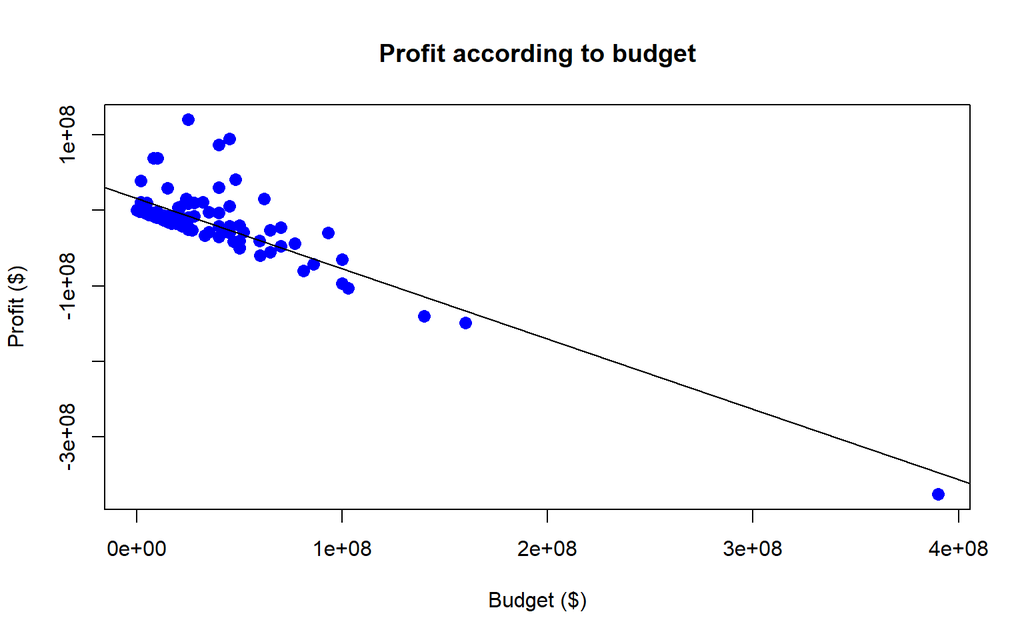

```r
plot(FrenchFilms$budget, FrenchFilms$profit,  # defining abscissa then ordinate of the points
    pch = 16, cex = 1.3, col = "blue",  # defining the shape, size, color of the points
    main = "Profit according to budget", # defining the labels of the graph
    xlab = "Budget ($)", ylab = "Profit ($)" # and the axes
    )
abline(Model1) # adding the regression line to the previous plot - must be run simultaneously with the plot()
```

##### Your answers (please write down your answer here)

[^1]: the database is freely accessible on : [Kaggle](https://www.kaggle.com/tmdb/tmdb-movie-metadata)